# Summary of Output.

# QUALITY ASSESSMENT.

The code below reproduced quality control files on our sample data. The output was in the form of html files which have been added to this repo as well.

```bash
gzip $INDIR/*.fastq
fastqc $INDIR/*.gz --outdir $OUTWD/fastqc_files
cd $OUTWD/fastqc_files
multiqc . --force --outdir .
rm -rf *.zip
```

The output is in the quality control folder in the repo.

# ASSEMBLY

The code below was executed to run assembly using the unicycler program on our sample data. It assembled our forward and reverse reads producing assembeled contigs in the form of fasta files.

```bash
for sample in $(cat $OUTWD/list.txt); do
    mkdir -p $OUTWD/assembly/${sample}
    X=${sample}_trim1.fastq.gz
    Y=${sample}_trim2.fastq.gz
    unicycler -1 $INDIR/$X -2 $INDIR/$Y -t $CPUS -o $OUTWD/assembly/${sample}
    mv $OUTWD/assembly/${sample}/assembly.fasta $OUTWD/assembly/${sample}/${sample}.fasta
done
```

The assembly files are found in the repo in the assembly folder.

# ASSEMBLY QUALITY ASSESSMENT

The code below assessed the quality of the assemblies we generated previously. Displaying measures such N50 and L50 to ascertain the quality of the assembly.

```bash
for n in $(cat $OUTWD/list.txt); do
    quast $OUTWD/assembly/${n}/${n}.fasta -o $OUTWD/quality_assembly/${n}_stats -t $CPUS --min-contig 200 --silent
done
```

The quality output is in the quality folder in the repo

# ANNOTATION

The code below provided annotations to our assembled files.

```bash
for x in $(cat $OUTWD/list.txt); do
    mkdir -p $OUTWD/assembly/${x}
    prokka --outdir $OUTWD/annotation/${x} --prefix ${x} $OUTWD/assembly/${x}/$x.fasta --cpus $CPUS --locustag $x
done
```

The output is in the annotation folder in the repo.

# AMR,PLASMIDS,VIRULENCE

The code below carried determined the AMR profile, plasmids present and the virulence factors in all our samples.

# AMR

```bash
abricate --setupdb
for sample in $(cat $OUTWD/list.txt); do
    mkdir -p $OUTWD/resistome/ABRICATE/${sample}
    for i in resfinder card argannot ncbi; do
        abricate $OUTWD/assembly/${sample}/${sample}.fasta --threads 8 --nopath --db $i >$OUTWD/resistome/ABRICATE/${sample}/$sample_$i.tab
        abricate --summary $OUTWD/resistome/ABRICATE/${sample}/*.tab >$OUTWD/resistome/ABRICATE/${sample}/summary.tab
    done
done
```

The output was summarized into one tab separated file showing all the AMR data of our samples.

```r
AMR <- read.table("Summary-of-AMR.tsv", fill = TRUE)
head(AMR)
```

```
##                                                                      V1 V2
## 1  miniproject-run/resistance_genes/ABRICATE/Catt-BWE_048B/argannot.tab 10
## 2      miniproject-run/resistance_genes/ABRICATE/Catt-BWE_048B/card.tab 46
## 3   miniproject-run/resistance_genes/ABRICATE/Catt-BWE_048B/megares.tab 51
## 4      miniproject-run/resistance_genes/ABRICATE/Catt-BWE_048B/ncbi.tab  7
## 5 miniproject-run/resistance_genes/ABRICATE/Catt-BWE_048B/resfinder.tab  6
## 6   miniproject-run/resistance_genes/ABRICATE/Catt-BWE_048B/summary.tab  0
##       V3    V4    V5     V6     V7     V8     V9    V10    V11    V12    V13
## 1 100.00 88.89 85.75 100.00 100.00 100.00 100.00 100.00 100.00 100.00      .
## 2      .     .     .      .      .      .      .      .      .      .      .
## 3      .     .     .      .      .      .      .      .      .      . 100.00
## 4      .     .     .      .      .      .      .      .      .      .      .
## 5      .     .     .      .      .      .      .      .      .      .      .
## 6      .     .     .      .      .      .      .      .      .      .      .
##      V14    V15    V16    V17    V18    V19    V20   V21    V22   V23   V24
```

[output cut: 69 more lines]

# Plasmids and virulence factors

```bash
for sample in $(cat $OUTWD/list.txt); do
    abricate $OUTWD/assembly/${sample}/${sample}.fasta --threads 8 --nopath --db vfdb >$OUTWD/resistome/virulence_factors/$sample.tab
done
abricate --summary $OUTWD/resistome/virulence_factors/*.tab >$OUTWD/resistome/virulence_factors/summary-vf.tab
```

```r
Plasmids <- read.table("summary-plasmids.tab", fill = TRUE)
print(Plasmids)
```

```
##                                              V1 V2     V3     V4     V5    V6
## 1    miniproject-run/plasmids/Catt-BWE_048B.tab  1      .      .      .     .
## 2    miniproject-run/plasmids/Catt-BWE_054A.tab  1      .      .      .     .
## 3    miniproject-run/plasmids/Catt-BWE_113B.tab  3      .      .      .     .
## 4    miniproject-run/plasmids/Catt-HIM_031B.tab  2      .      .      .     .
## 5    miniproject-run/plasmids/Catt-HIM_045B.tab  2      .      .      .     .
## 6    miniproject-run/plasmids/Catt-HIM_048B.tab  4      .      .      .     .
## 7    miniproject-run/plasmids/Catt-HIM_068A.tab  3      .      .      .     .
## 8    miniproject-run/plasmids/Catt-HIM_073A.tab  1      .      .      .     .
## 9   miniproject-run/plasmids/Catt-HIM_082A1.tab  3      .      .      .     .
## 10 miniproject-run/plasmids/Catt-KAT_009_A1.tab  2      .      .      .     .
## 11  miniproject-run/plasmids/Catt-KAT_013A1.tab  4      .      .      .     .
## 12   miniproject-run/plasmids/Catt-KAT_036B.tab  2      .      .      .     .
## 13   miniproject-run/plasmids/Home-BWE_054A.tab  2      .      .      .     .
## 14   miniproject-run/plasmids/Home-HIM_031A.tab  0      .      .      .     .
```

[output cut: 157 more lines]

# MLST

The code below carried out Multi-Locus Sequence Typing on our sample.

```bash
for w in $(cat $OUTWD/list.txt); do
    mlst --threads $CPUS $OUTWD/assembly/${w}/${w}.fasta >$OUTWD/mlsts/${w}_mlst.tsv
done
```

```r
MLST <- read.table("Summary-mlst.tsv", fill = TRUE)
print(MLST)
```

```
##                                                             V1        V2   V3
## 1      miniproject-run/assembly/Catt-BWE_048B/Catt-BWE_048B.fa     ecoli    -
## 2      miniproject-run/assembly/Catt-BWE_054A/Catt-BWE_054A.fa     ecoli 8927
## 3      miniproject-run/assembly/Catt-BWE_113B/Catt-BWE_113B.fa     ecoli    -
## 4      miniproject-run/assembly/Catt-HIM_031B/Catt-HIM_031B.fa     ecoli    -
## 5      miniproject-run/assembly/Catt-HIM_045B/Catt-HIM_045B.fa     ecoli    -
## 6      miniproject-run/assembly/Catt-HIM_048B/Catt-HIM_048B.fa     ecoli   48
## 7      miniproject-run/assembly/Catt-HIM_068A/Catt-HIM_068A.fa     ecoli  162
## 8      miniproject-run/assembly/Catt-HIM_073A/Catt-HIM_073A.fa     ecoli    -
## 9    miniproject-run/assembly/Catt-HIM_082A1/Catt-HIM_082A1.fa     ecoli    -
## 10 miniproject-run/assembly/Catt-KAT_009_A1/Catt-KAT_009_A1.fa     ecoli   10
## 11   miniproject-run/assembly/Catt-KAT_013A1/Catt-KAT_013A1.fa     ecoli  602
## 12     miniproject-run/assembly/Catt-KAT_036B/Catt-KAT_036B.fa         -    -
## 13     miniproject-run/assembly/Home-BWE_054A/Home-BWE_054A.fa     ecoli    2
## 14     miniproject-run/assembly/Home-HIM_031A/Home-HIM_031A.fa     ecoli  348
```

[output cut: 114 more lines]

# VARIANT CALLING

The code below carried out variant calling on our sample data and produced VCF files.

```bash
mkdir -p $OUTWD/snps
for c in $(cat $OUTWD/list.txt); do
    mkdir -p $OUTWD/snps/${c}
    X=${c}_trim1.fastq.gz
    Y=${c}_trim2.fastq.gz
    snippy --cpus $CPUS --outdir $OUTWD/snps/${c} --ref $REFERENCE --R1 $INDIR/$X --R2 $INDIR/$Y --force
done
```

The output is in the variant calling folder in the repo. But the vcf files generated should look like this.

```r
VCF <- read.table("Summary-of-VCF.tsv", fill = TRUE)
head(VCF)
```

```
##            V1   V2 V3   V4   V5      V6 V7
## 1 NC_000913.3  892  .    C    T 340.751  .
## 2 NC_000913.3  939  .    G    A 345.810  .
## 3 NC_000913.3 1299  . TGGT CGGC 341.309  .
## 4 NC_000913.3 1317  .    G    A 349.259  .
## 5 NC_000913.3 1407  .    C    T 310.575  .
## 6 NC_000913.3 1425  .    A    G 310.582  .
##                                               V8                   V9
## 1     AB=0;AO=11;DP=11;QA=398;QR=0;RO=0;TYPE=snp GT:DP:RO:QR:AO:QA:GL
## 2     AB=0;AO=11;DP=11;QA=402;QR=0;RO=0;TYPE=snp GT:DP:RO:QR:AO:QA:GL
## 3 AB=0;AO=11;DP=11;QA=404;QR=0;RO=0;TYPE=complex GT:DP:RO:QR:AO:QA:GL
## 4     AB=0;AO=11;DP=11;QA=409;QR=0;RO=0;TYPE=snp GT:DP:RO:QR:AO:QA:GL
## 5     AB=0;AO=10;DP=10;QA=366;QR=0;RO=0;TYPE=snp GT:DP:RO:QR:AO:QA:GL
## 6     AB=0;AO=10;DP=10;QA=366;QR=0;RO=0;TYPE=snp GT:DP:RO:QR:AO:QA:GL
##                                     V10
## 1 1/1:11:0:0:11:398:-36.1613,-3.31133,0
## 2 1/1:11:0:0:11:402:-36.5211,-3.31133,0
## 3 1/1:11:0:0:11:404:-36.3632,-3.31133,0
## 4 1/1:11:0:0:11:409:-37.1583,-3.31133,0
## 5  1/1:10:0:0:10:366:-33.2856,-3.0103,0
## 6  1/1:10:0:0:10:366:-33.2863,-3.0103,0
```

# PANGENOME ANALYSIS

The code below produced carried out pangenome analysis of our samples.

```bash
SVG_CONVERT="$eTrackDIR/../files/roary2svg.pl"
CAIRO_SVG="$(which cairosvg)"
mkdir -p $OUTWD/gff
for c in $(cat $OUTWD/list.txt); do
    cp -rf $OUTWD/annotation/${c}/${c}.gff $OUTWD/gff
done
roary -e -n -f $OUTWD/pangenome -p $CPUS $OUTWD/gff/*.gff
perl $SVG_CONVERT $OUTWD/pangenome/gene_presence_absence.csv --colour=Blue >$OUTWD/pangenome/pangenome.svg
$CAIRO_SVG $OUTWD/pangenome/pangenome.svg -o $OUTWD/pangenome/pangenome.png
rm -rf $OUTWD/gff
```

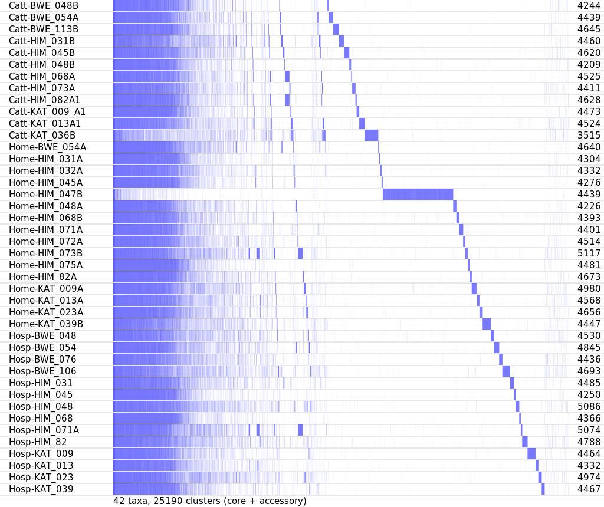

*Pangenome analysis*.

# PHYLOGENETICS

The code below produced phylogenetic trees of our samples based on a core genome alignment of all our samples.

```bash
for i in $(cat $OUTWD/list.txt); do cp $OUTWD/assembly/${i}/${i}.fasta $OUTWD/phylogenetics/; done
parsnp -r $REFERENCE -d $OUTWD/phylogenetics/ -p $CPUS -c --use-ani -n mafft -u -o $OUTWD/phylogenetics/Phylogenetic_Tree/
rm $OUTWD/phylogenetics/*.fasta
```

The trees show the distance between species and clades.

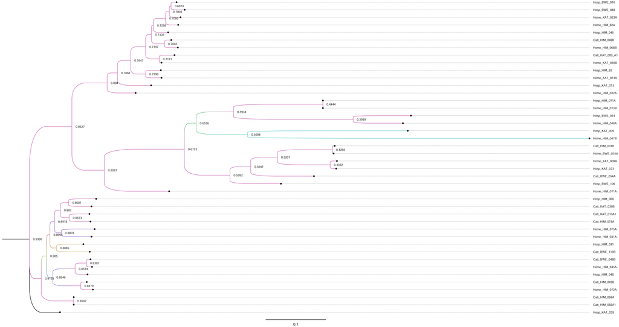

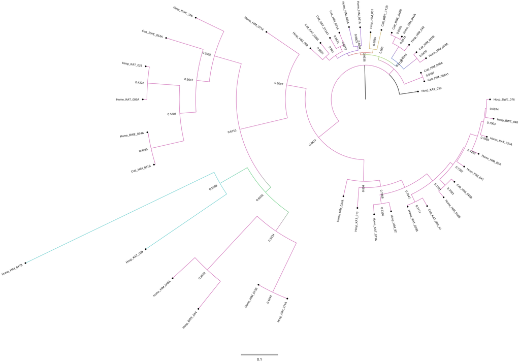